# Berlin Airbnb Rental Demand Prediction - Exploratory Data Analysis

Data Science Team

2025-03-16

# Introduction

This document contains the exploratory data analysis (EDA) for the Airbnb Berlin rental demand prediction project. The goal is to gain insights from the data and identify patterns that will inform our predictive modeling approach.

## Data Loading

First, we need to load the dataset from the data directory.

```r
# Set the file path to the existing data
data_path <- "../data/"

# Load the train and test datasets
train_data <- read.csv(paste0(data_path, "train_airbnb_berlin.csv"))
test_data <- read.csv(paste0(data_path, "test_airbnb_berlin.csv"))

# Display basic information about the datasets
cat("Train dataset dimensions:", dim(train_data)[1], "rows,", dim(train_data)[2], "columns\n")
```

```
## Train dataset dimensions: 15692 rows, 39 columns
```

```r
cat("Test dataset dimensions:", dim(test_data)[1], "rows,", dim(test_data)[2], "columns\n")
```

```
## Test dataset dimensions: 7842 rows, 38 columns
```

```r
# Preview train data
kable(head(train_data))
```

| Listing.ID | Listing.Name | Host.ID | Host.Name | Host.Since | Host.Response.Time | Host.Response.Rate | Is.Superhost | neighbourhood | Neighborhood.Group | City | Postal.Code | Country.Code | Country | Latitude | Longitude | Is.Exact.Location | Property.Type | Room.Type | Accomodates | Bathrooms | Bedrooms | Beds | Square.Feet | Guests.Included | Min.Nights | Reviews | First.Review | Last.Review | Overall.Rating | … |
| --- | --- | --- | --- | --- | --- | --- | --- | --- | --- | --- | --- | --- | --- | --- | --- | --- | --- | --- | --- | --- | --- | --- | --- | --- | --- | --- | --- | --- | --- | --- |
| 19665213 | * | 156079597 | Maximilian | 2016-01-20 |  |  | f | Prenzlauer Berg | Pankow | Berlin | 10437.0 | DE | Germany | 52.54652 | 13.41792 | t | Apartment | Private room | 2 | 1.0 | 1.0 | 1.0 | NA | 1 | 2 | 6 | 2017-07-07 | 2017-08-08 | 100 | … |
| 6436842 | * | 5302290 | Dulie | 2013-04-07 |  |  | f | Pankow | Pankow | Berlin | 13187.0 | DE | Germany | 52.56512 | 13.42214 | t | Apartment | Entire home/apt | 2 | 1.0 | 2.0 | 2.0 | NA | 2 | 7 | 6 | 2015-05-26 | 2019-04-30 | 90 | … |
| 10559468 | * | 59151456 | Geank | 2016-02-07 |  |  | f | Prenzlauer Berg | Pankow | Berlin | 10439.0 | DE | Germany | 52.54741 | 13.42521 | t | Apartment | Entire home/apt | 3 | 1.0 | 1.0 | 2.0 | NA | 1 | 1 | 2 | 2016-04-19 | 2016-07-04 | 100 | … |
| 27215482 | * | 193452785 | Alix | 2018-06-26 |  |  | f | Friedrichshain | Friedrichshain-Kreuzberg | Berlin | 10245 | DE | Germany | 52.50958 | 13.45144 | t | Apartment | Private room | 2 | 1.0 | 1.0 | 1.0 | NA | 1 | 2 | 4 | 2018-07-31 | 2018-08-12 | 100 | … |
| 27287546 | * | 205870244 | Lurina | 2013-05-16 | within a few hours | 92% | t | Prenzlauer Berg | Pankow | Berlin | 10405.0 | DE | Germany | 52.52995 | 13.41558 | t | Apartment | Private room | 3 | 1.0 | 1.0 | 2.0 | NA | 1 | 6 | 0 |  |  | NA | … |
| 26590915 | * | 90250336 | Zan | 2016-08-22 | within an hour | 100% | t | Mariendorf | Tempelhof - SchÃ¶neberg | Berlin | * | DE | Germany | 52.44826 | 13.40608 | t | Condominium | Private room | 3 | 1.0 | 1.0 | 2.0 | NA | 2 | 1 | 10 | 2018-09-25 | 2019-05-03 | 99 | … |

## Data Structure and Types

Let’s examine the structure and summary statistics of our data.

```r
# Check column names
colnames(train_data)
```

```
##  [1] "Listing.ID"            "Listing.Name"          "Host.ID"
##  [4] "Host.Name"             "Host.Since"            "Host.Response.Time"
##  [7] "Host.Response.Rate"    "Is.Superhost"          "neighbourhood"
## [10] "Neighborhood.Group"    "City"                  "Postal.Code"
## [13] "Country.Code"          "Country"               "Latitude"
## [16] "Longitude"             "Is.Exact.Location"     "Property.Type"
## [19] "Room.Type"             "Accomodates"           "Bathrooms"
## [22] "Bedrooms"              "Beds"                  "Square.Feet"
## [25] "Guests.Included"       "Min.Nights"            "Reviews"
## [28] "First.Review"          "Last.Review"           "Overall.Rating"
## [31] "Accuracy.Rating"       "Cleanliness.Rating"    "Checkin.Rating"
## [34] "Communication.Rating"  "Location.Rating"       "Value.Rating"
## [37] "Instant.Bookable"      "Business.Travel.Ready" "Price"
```

```r
# Check data types for each column
str(train_data)
```

```
## 'data.frame':    15692 obs. of  39 variables:
##  $ Listing.ID           : num  19665213 6436842 10559468 27215482 27287546 ...
##  $ Listing.Name         : chr  "*" "*" "*" "*" ...
##  $ Host.ID              : num  1.56e+08 5.30e+06 5.92e+07 1.93e+08 2.06e+08 ...
##  $ Host.Name            : chr  "Maximilian" "Dulie" "Geank" "Alix" ...
##  $ Host.Since           : chr  "2016-01-20" "2013-04-07" "2016-02-07" "2018-06-26" ...
##  $ Host.Response.Time   : chr  "" "" "" "" ...
##  $ Host.Response.Rate   : chr  "" "" "" "" ...
##  $ Is.Superhost         : chr  "f" "f" "f" "f" ...
##  $ neighbourhood        : chr  "Prenzlauer Berg" "Pankow" "Prenzlauer Berg" "Friedrichshain" ...
##  $ Neighborhood.Group   : chr  "Pankow" "Pankow" "Pankow" "Friedrichshain-Kreuzberg" ...
##  $ City                 : chr  "Berlin" "Berlin" "Berlin" "Berlin" ...
##  $ Postal.Code          : chr  "10437.0" "13187.0" "10439.0" "10245" ...
##  $ Country.Code         : chr  "DE" "DE" "DE" "DE" ...
##  $ Country              : chr  "Germany" "Germany" "Germany" "Germany" ...
```

[output cut: 25 more lines]

```r
# Summary statistics
summary(train_data)
```

```
##    Listing.ID       Listing.Name          Host.ID           Host.Name
##  Min.   :   22415   Length:15692       Min.   :    11015   Length:15692
##  1st Qu.: 9052831   Class :character   1st Qu.:  9274528   Class :character
##  Median :18650372   Mode  :character   Median : 33581823   Mode  :character
##  Mean   :17800618                      Mean   : 61190420
##  3rd Qu.:26113085                      3rd Qu.: 93256775
##  Max.   :34674496                      Max.   :260969848
##  NA's   :1
##   Host.Since        Host.Response.Time Host.Response.Rate Is.Superhost
##  Length:15692       Length:15692       Length:15692       Length:15692
##  Class :character   Class :character   Class :character   Class :character
##  Mode  :character   Mode  :character   Mode  :character   Mode  :character
##
##
##
##
##  neighbourhood      Neighborhood.Group     City           Postal.Code
##  Length:15692       Length:15692       Length:15692       Length:15692
##  Class :character   Class :character   Class :character   Class :character
##  Mode  :character   Mode  :character   Mode  :character   Mode  :character
##
##
##
##
##  Country.Code         Country             Latitude       Longitude
##  Length:15692       Length:15692       Min.   :52.37   Min.   :13.12
##  Class :character   Class :character   1st Qu.:52.49   1st Qu.:13.38
##  Mode  :character   Mode  :character   Median :52.51   Median :13.42
##                                        Mean   :52.51   Mean   :13.41
##                                        3rd Qu.:52.53   3rd Qu.:13.44
##                                        Max.   :52.64   Max.   :13.71
##
##  Is.Exact.Location  Property.Type       Room.Type         Accomodates
##  Length:15692       Length:15692       Length:15692       Length:15692
##  Class :character   Class :character   Class :character   Class :character
##  Mode  :character   Mode  :character   Mode  :character   Mode  :character
##
##
##
##
```

[output cut: 25 more lines]

```
##  Min.   : 2.000   Min.   : 2.000       Min.   : 2.000   Min.   : 2.000
##  1st Qu.:10.000   1st Qu.:10.000       1st Qu.: 9.000   1st Qu.: 9.000
##  Median :10.000   Median :10.000       Median :10.000   Median :10.000
##  Mean   : 9.769   Mean   : 9.779       Mean   : 9.557   Mean   : 9.458
##  3rd Qu.:10.000   3rd Qu.:10.000       3rd Qu.:10.000   3rd Qu.:10.000
##  Max.   :10.000   Max.   :10.000       Max.   :10.000   Max.   :10.000
##  NA's   :2973     NA's   :2970         NA's   :2971     NA's   :2972
##  Instant.Bookable   Business.Travel.Ready     Price
##  Length:15692       Length:15692          Min.   :  8.00
##  Class :character   Class :character      1st Qu.: 32.00
##  Mode  :character   Mode  :character      Median : 49.00
##                                           Mean   : 60.34
##                                           3rd Qu.: 70.00
##                                           Max.   :900.00
##                                           NA's   :9
```

```r
# Use skimr for a more comprehensive summary
skim(train_data)
```

Data summary

| Name | train_data |
| --- | --- |
| Number of rows | 15692 |
| Number of columns | 39 |
| _______________________ |  |
| Column type frequency: |  |
| character | 25 |
| numeric | 14 |
| ________________________ |  |
| Group variables | None |

**Variable type: character**

| skim_variable | n_missing | complete_rate | min | max | empty | n_unique | whitespace |
| --- | --- | --- | --- | --- | --- | --- | --- |
| Listing.Name | 0 | 1 | 0 | 1 | 54 | 2 | 0 |
| Host.Name | 0 | 1 | 0 | 34 | 22 | 11509 | 0 |
| Host.Since | 0 | 1 | 0 | 10 | 21 | 3030 | 0 |
| Host.Response.Time | 0 | 1 | 0 | 18 | 7075 | 5 | 0 |
| Host.Response.Rate | 0 | 1 | 0 | 4 | 7075 | 35 | 0 |
| Is.Superhost | 0 | 1 | 0 | 1 | 23 | 3 | 0 |
| neighbourhood | 0 | 1 | 1 | 21 | 0 | 63 | 0 |
| Neighborhood.Group | 0 | 1 | 5 | 24 | 0 | 12 | 0 |
| City | 0 | 1 | 0 | 6 | 1 | 3 | 0 |
| Postal.Code | 0 | 1 | 0 | 7 | 229 | 186 | 0 |
| Country.Code | 0 | 1 | 2 | 2 | 0 | 1 | 0 |
| Country | 0 | 1 | 7 | 7 | 0 | 1 | 0 |
| Is.Exact.Location | 0 | 1 | 1 | 1 | 0 | 2 | 0 |
| Property.Type | 0 | 1 | 1 | 18 | 0 | 16 | 0 |
| Room.Type | 0 | 1 | 11 | 15 | 0 | 3 | 0 |
| Accomodates | 0 | 1 | 1 | 2 | 0 | 13 | 0 |
| Bathrooms | 0 | 1 | 0 | 3 | 14 | 9 | 0 |
| Bedrooms | 0 | 1 | 0 | 3 | 5 | 8 | 0 |
| Beds | 0 | 1 | 0 | 4 | 8 | 13 | 0 |
| Guests.Included | 0 | 1 | 1 | 1 | 0 | 8 | 0 |
| Min.Nights | 0 | 1 | 1 | 3 | 0 | 25 | 0 |
| First.Review | 0 | 1 | 0 | 10 | 2705 | 2244 | 0 |
| Last.Review | 0 | 1 | 0 | 10 | 2706 | 1451 | 0 |
| Instant.Bookable | 0 | 1 | 1 | 1 | 0 | 2 | 0 |
| Business.Travel.Ready | 0 | 1 | 1 | 1 | 0 | 1 | 0 |

**Variable type: numeric**

| skim_variable | n_missing | complete_rate | mean | sd | p0 | p25 | p50 | p75 | p100 | hist |
| --- | --- | --- | --- | --- | --- | --- | --- | --- | --- | --- |
| Listing.ID | 1 | 1.00 | 17800618.34 | 9952544.25 | 22415.00 | 9052831.00 | 18650372.00 | 26113085.00 | 34674496.00 | ▇▇▇▇▇ |
| Host.ID | 0 | 1.00 | 61190419.66 | 67394205.32 | 11015.00 | 9274527.75 | 33581823.00 | 93256774.75 | 260969848.00 | ▇▂▁▁▁ |
| Latitude | 0 | 1.00 | 52.51 | 0.03 | 52.37 | 52.49 | 52.51 | 52.53 | 52.64 | ▁▂▇▃▁ |
| Longitude | 0 | 1.00 | 13.41 | 0.06 | 13.12 | 13.38 | 13.42 | 13.44 | 13.71 | ▁▂▇▁▁ |
| Square.Feet | 15389 | 0.02 | 445.90 | 414.82 | 0.00 | 0.00 | 440.00 | 700.00 | 1912.00 | ▇▇▂▁▁ |
| Reviews | 0 | 1.00 | 19.45 | 39.48 | 0.00 | 1.00 | 5.00 | 17.00 | 424.00 | ▇▁▁▁▁ |
| Overall.Rating | 2962 | 0.81 | 94.72 | 7.07 | 20.00 | 93.00 | 97.00 | 100.00 | 100.00 | ▁▁▁▁▇ |
| Accuracy.Rating | 2971 | 0.81 | 9.72 | 0.67 | 2.00 | 10.00 | 10.00 | 10.00 | 10.00 | ▁▁▁▁▇ |
| Cleanliness.Rating | 2970 | 0.81 | 9.33 | 1.02 | 2.00 | 9.00 | 10.00 | 10.00 | 10.00 | ▁▁▁▁▇ |
| Checkin.Rating | 2973 | 0.81 | 9.77 | 0.62 | 2.00 | 10.00 | 10.00 | 10.00 | 10.00 | ▁▁▁▁▇ |
| Communication.Rating | 2970 | 0.81 | 9.78 | 0.62 | 2.00 | 10.00 | 10.00 | 10.00 | 10.00 | ▁▁▁▁▇ |
| Location.Rating | 2971 | 0.81 | 9.56 | 0.73 | 2.00 | 9.00 | 10.00 | 10.00 | 10.00 | ▁▁▁▁▇ |
| Value.Rating | 2972 | 0.81 | 9.46 | 0.79 | 2.00 | 9.00 | 10.00 | 10.00 | 10.00 | ▁▁▁▁▇ |
| Price | 9 | 1.00 | 60.34 | 48.83 | 8.00 | 32.00 | 49.00 | 70.00 | 900.00 | ▇▁▁▁▁ |

# Initial Data Exploration

## Missing Values

Let’s examine missing values in the dataset.

```r
# Count missing values in each column
missing_train <- colSums(is.na(train_data))
missing_test <- colSums(is.na(test_data))

# Display columns with missing values
missing_train[missing_train > 0]
```

```
##           Listing.ID          Square.Feet       Overall.Rating
##                    1                15389                 2962
##      Accuracy.Rating   Cleanliness.Rating       Checkin.Rating
##                 2971                 2970                 2973
## Communication.Rating      Location.Rating         Value.Rating
##                 2970                 2971                 2972
##                Price
##                    9
```

```r
missing_test[missing_test > 0]
```

```
##           Listing.ID              Host.ID          Square.Feet
##                    1                    1                 7694
##       Overall.Rating      Accuracy.Rating   Cleanliness.Rating
##                 1515                 1519                 1518
##       Checkin.Rating Communication.Rating      Location.Rating
##                 1522                 1520                 1522
##         Value.Rating
##                 1521
```

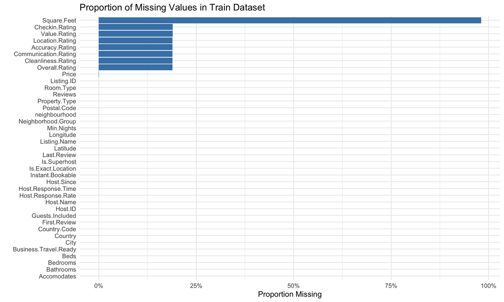

```r
# Visualize missing values
train_data %>%
  summarise(across(everything(), ~sum(is.na(.))/n())) %>%
  gather() %>%
  ggplot(aes(x = reorder(key, value), y = value)) +
  geom_bar(stat = "identity", fill = "steelblue") +
  coord_flip() +
  labs(title = "Proportion of Missing Values in Train Dataset",
       x = "",
       y = "Proportion Missing") +
  theme_minimal() +
  scale_y_continuous(labels = scales::percent)
```

## Price Distribution Analysis

```r
# Check if there's a price column
if("price" %in% names(train_data)) {
  # Basic statistics
  price_stats <- summary(train_data$price)
  print(price_stats)

  # Price distribution
  ggplot(train_data, aes(x = price)) +
    geom_histogram(bins = 50, fill = "steelblue", alpha = 0.7) +
    labs(title = "Distribution of Airbnb Prices in Berlin",
         x = "Price (Euro)",
         y = "Count") +
    theme_minimal()

  # Price distribution with log transformation (for skewed data)
  ggplot(train_data, aes(x = price)) +
    geom_histogram(bins = 50, fill = "steelblue", alpha = 0.7) +
    scale_x_log10() +
    labs(title = "Distribution of Airbnb Prices in Berlin (Log Scale)",
         x = "Price (Euro) - Log Scale",
         y = "Count") +
    theme_minimal()

  # Price boxplot
  ggplot(train_data, aes(y = price)) +
    geom_boxplot(fill = "steelblue", alpha = 0.7) +
    labs(title = "Boxplot of Airbnb Prices in Berlin",
         y = "Price (Euro)") +
    theme_minimal()
}
```

## Geographic Analysis

```r
# Check if we have latitude and longitude
if(all(c("latitude", "longitude") %in% names(train_data))) {
  # Create a leaflet map
  leaflet_map <- leaflet(train_data) %>%
    addTiles() %>%
    addCircleMarkers(
      lng = ~longitude,
      lat = ~latitude,
      radius = 2,
      color = "blue",
      fillOpacity = 0.5,
      popup = ~paste("Price:", price, "<br>",
                    "Room Type:", room_type)
    ) %>%
    addControl(html = "<b>Airbnb Listings in Berlin</b>", position = "topright")

  # Display the map
  leaflet_map

  # Plot price heatmap by location
  if("price" %in% names(train_data)) {
    # Create bins for price
    train_data$price_bin <- cut(train_data$price,
                               breaks = c(0, 50, 100, 150, 200, Inf),
                               labels = c("< 50", "50-100", "100-150", "150-200", "> 200"))

    # Color palette
    price_pal <- colorFactor(
      palette = c("green", "blue", "purple", "orange", "red"),
      domain = train_data$price_bin
    )

    # Create a leaflet map with price colors
    price_map <- leaflet(train_data) %>%
      addTiles() %>%
      addCircleMarkers(
        lng = ~longitude,
        lat = ~latitude,
        radius = 2,
        color = ~price_pal(price_bin),
        fillOpacity = 0.7,
        popup = ~paste("Price:", price, "<br>",
                      "Room Type:", room_type)
      ) %>%
      addLegend("bottomright",
                pal = price_pal,
                values = ~price_bin,
                title = "Price (Euro)",
                opacity = 1)

    # Display the map
    price_map
  }
}
```

## Neighborhood Analysis

```r
# Check if neighborhood information is available
if("neighbourhood" %in% names(train_data) || "neighborhood" %in% names(train_data)) {
  # Determine which column to use
  neighborhood_col <- ifelse("neighbourhood" %in% names(train_data), "neighbourhood", "neighborhood")

  # Count listings by neighborhood
  neighborhood_counts <- train_data %>%
    count(!!sym(neighborhood_col)) %>%
    arrange(desc(n))

  # Top 15 neighborhoods by listing count
  top_neighborhoods <- head(neighborhood_counts, 15)
  kable(top_neighborhoods, caption = "Top 15 Neighborhoods by Number of Listings")

  # Visualize neighborhood distribution
  ggplot(top_neighborhoods, aes(x = reorder(!!sym(neighborhood_col), n), y = n)) +
    geom_bar(stat = "identity", fill = "steelblue") +
    coord_flip() +
    labs(title = "Top 15 Neighborhoods by Number of Listings",
         x = "Neighborhood",
         y = "Number of Listings") +
    theme_minimal()

  # If price is available, analyze price by neighborhood
  if("price" %in% names(train_data)) {
    # Calculate average price by neighborhood
    avg_price_by_neighborhood <- train_data %>%
      group_by(!!sym(neighborhood_col)) %>%
      summarise(
        avg_price = mean(price, na.rm = TRUE),
        median_price = median(price, na.rm = TRUE),
        count = n()
      ) %>%
      filter(count >= 10) %>%  # Only include neighborhoods with at least 10 listings
      arrange(desc(avg_price))

    # Top 15 neighborhoods by average price
    top_price_neighborhoods <- head(avg_price_by_neighborhood, 15)
    kable(top_price_neighborhoods, caption = "Top 15 Neighborhoods by Average Price")

    # Visualize average price by neighborhood
    ggplot(top_price_neighborhoods,
           aes(x = reorder(!!sym(neighborhood_col), avg_price), y = avg_price)) +
      geom_bar(stat = "identity", fill = "steelblue") +
      geom_text(aes(label = round(avg_price, 0)), hjust = -0.1, size = 3) +
      coord_flip() +
      labs(title = "Top 15 Neighborhoods by Average Price",
           x = "Neighborhood",
           y = "Average Price (Euro)") +
      theme_minimal()

    # Price distribution by neighborhood (box plots)
    # Select top 10 neighborhoods by listing count for readability
    top10_neighborhoods <- neighborhood_counts$neighbourhood[1:10]

    train_data %>%
      filter(!!sym(neighborhood_col) %in% top10_neighborhoods) %>%
      ggplot(aes(x = reorder(!!sym(neighborhood_col), price, FUN = median), y = price)) +
      geom_boxplot(fill = "steelblue", alpha = 0.7) +
      coord_flip() +
      labs(title = "Price Distribution by Neighborhood",
           x = "Neighborhood",
           y = "Price (Euro)") +
      theme_minimal()
  }
}
```

## Property and Room Type Analysis

```r
# Check if property_type exists
if("property_type" %in% names(train_data)) {
  # Distribution of property types
  property_counts <- train_data %>%
    count(property_type) %>%
    arrange(desc(n))

  # Show top property types
  kable(head(property_counts, 10), caption = "Top 10 Property Types")

  # Visualize property type distribution
  ggplot(head(property_counts, 10), aes(x = reorder(property_type, n), y = n)) +
    geom_bar(stat = "identity", fill = "steelblue") +
    coord_flip() +
    labs(title = "Top 10 Property Types",
         x = "Property Type",
         y = "Count") +
    theme_minimal()
}

# Check if room_type exists
if("room_type" %in% names(train_data)) {
  # Distribution of room types
  room_counts <- train_data %>%
    count(room_type) %>%
    arrange(desc(n))

  # Show room types
  kable(room_counts, caption = "Distribution of Room Types")

  # Visualize room type distribution
  ggplot(room_counts, aes(x = reorder(room_type, n), y = n)) +
    geom_bar(stat = "identity", fill = "steelblue") +
    coord_flip() +
    labs(title = "Distribution of Room Types",
         x = "Room Type",
         y = "Count") +
    theme_minimal()

  # If price is available, analyze average price by room type
  if("price" %in% names(train_data)) {
    avg_price_by_room <- train_data %>%
      group_by(room_type) %>%
      summarise(
        avg_price = mean(price, na.rm = TRUE),
        median_price = median(price, na.rm = TRUE),
        count = n()
      ) %>%
      arrange(desc(avg_price))

    kable(avg_price_by_room, caption = "Average Price by Room Type")

    # Boxplot of price by room type
    ggplot(train_data, aes(x = room_type, y = price)) +
      geom_boxplot(fill = "steelblue", alpha = 0.7) +
      labs(title = "Price Distribution by Room Type",
           x = "Room Type",
           y = "Price (Euro)") +
      theme_minimal()
  }
}
```

## Accommodation and Amenities Analysis

```r
# Check if accommodates column exists
if("accommodates" %in% names(train_data)) {
  # Distribution of accommodation capacity
  accom_counts <- train_data %>%
    count(accommodates) %>%
    arrange(accommodates)

  kable(accom_counts, caption = "Distribution of Accommodation Capacity")

  # Visualize accommodation distribution
  ggplot(accom_counts, aes(x = as.factor(accommodates), y = n)) +
    geom_bar(stat = "identity", fill = "steelblue") +
    labs(title = "Distribution of Accommodation Capacity",
         x = "Number of People Accommodated",
         y = "Count") +
    theme_minimal()

  # If price is available, analyze relationship between capacity and price
  if("price" %in% names(train_data)) {
    avg_price_by_accom <- train_data %>%
      group_by(accommodates) %>%
      summarise(
        avg_price = mean(price, na.rm = TRUE),
        median_price = median(price, na.rm = TRUE),
        count = n()
      ) %>%
      arrange(accommodates)

    kable(avg_price_by_accom, caption = "Average Price by Accommodation Capacity")

    # Scatter plot with trend line
    ggplot(train_data, aes(x = accommodates, y = price)) +
      geom_point(alpha = 0.3, color = "steelblue") +
      geom_smooth(method = "lm", color = "red") +
      labs(title = "Relationship Between Accommodation Capacity and Price",
           x = "Number of People Accommodated",
           y = "Price (Euro)") +
      theme_minimal()

    # Boxplot of price by accommodation capacity
    ggplot(train_data, aes(x = as.factor(accommodates), y = price)) +
      geom_boxplot(fill = "steelblue", alpha = 0.7) +
      labs(title = "Price Distribution by Accommodation Capacity",
           x = "Number of People Accommodated",
           y = "Price (Euro)") +
      theme_minimal()
  }
}

# Check for bedrooms, beds, and bathrooms
bed_bath_columns <- c("bedrooms", "beds", "bathrooms")
existing_columns <- bed_bath_columns[bed_bath_columns %in% names(train_data)]

if(length(existing_columns) > 0 && "price" %in% names(train_data)) {
  # Create plots for each column
  for(col in existing_columns) {
    # Summary statistics
    col_summary <- train_data %>%
      group_by(!!sym(col)) %>%
      summarise(
        avg_price = mean(price, na.rm = TRUE),
        median_price = median(price, na.rm = TRUE),
        count = n()
      ) %>%
      arrange(!!sym(col))

    print(paste("Average price by", col))
    print(kable(col_summary))

    # Plot
    p <- ggplot(train_data, aes(x = as.factor(!!sym(col)), y = price)) +
      geom_boxplot(fill = "steelblue", alpha = 0.7) +
      labs(title = paste("Price Distribution by", tools::toTitleCase(col)),
           x = tools::toTitleCase(col),
           y = "Price (Euro)") +
      theme_minimal()

    print(p)
  }
}
```

## Reviews and Ratings Analysis

Let’s analyze review counts and ratings to understand their relationship with property demand.

```
##
## Summary of Overall.Rating :
##    Min. 1st Qu.  Median    Mean 3rd Qu.    Max.    NA's
##   20.00   93.00   97.00   94.72  100.00  100.00    2962
```

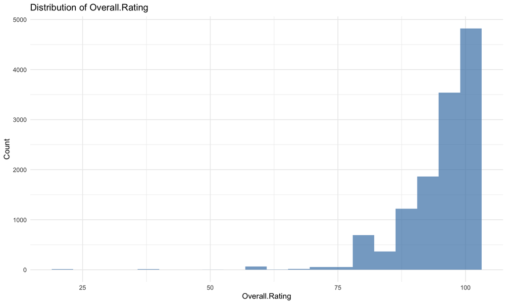

```
##
## Summary of Accuracy.Rating :
##    Min. 1st Qu.  Median    Mean 3rd Qu.    Max.    NA's
##   2.000  10.000  10.000   9.717  10.000  10.000    2971
```

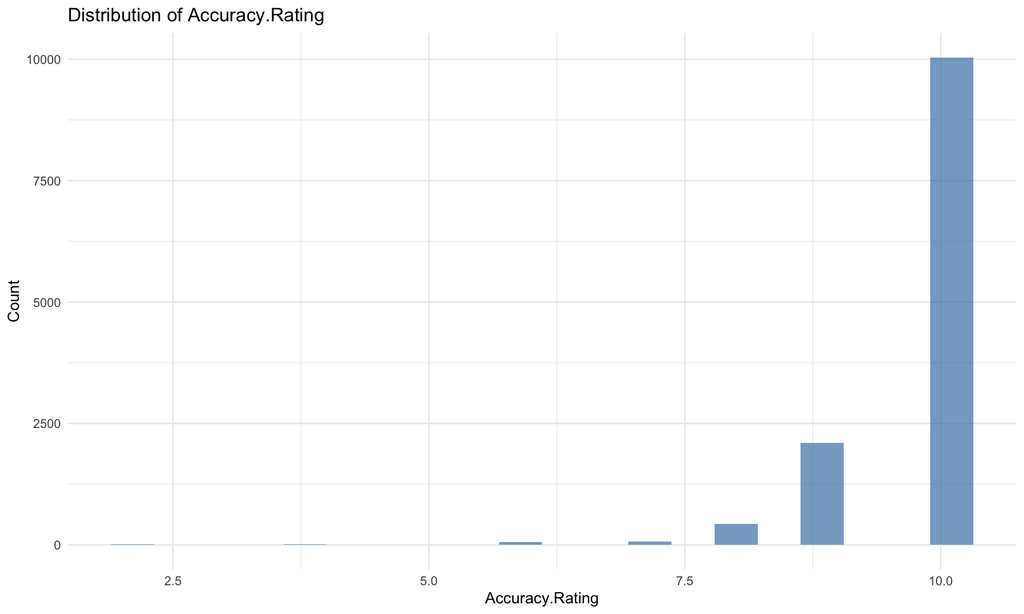

```
##
## Summary of Cleanliness.Rating :
##    Min. 1st Qu.  Median    Mean 3rd Qu.    Max.    NA's
##   2.000   9.000  10.000   9.328  10.000  10.000    2970
```

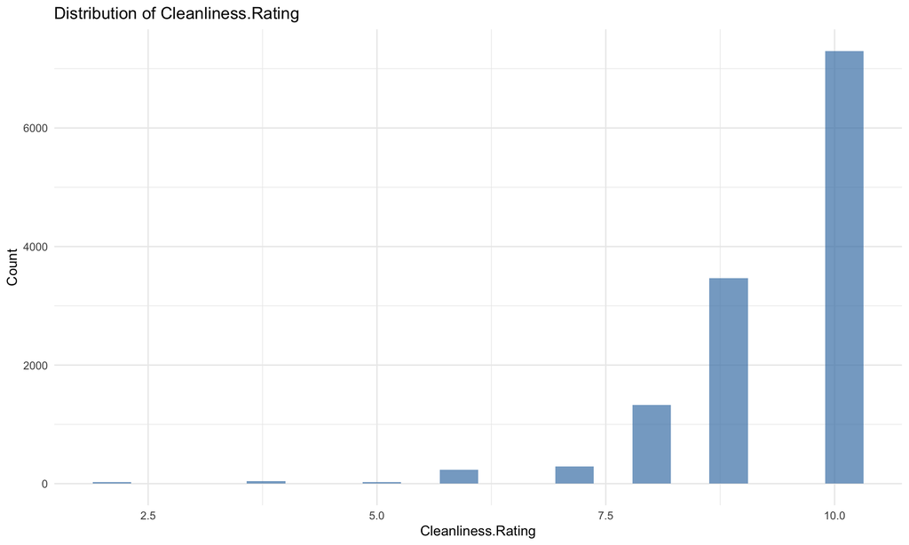

```
##
## Summary of Checkin.Rating :
##    Min. 1st Qu.  Median    Mean 3rd Qu.    Max.    NA's
##   2.000  10.000  10.000   9.769  10.000  10.000    2973
```

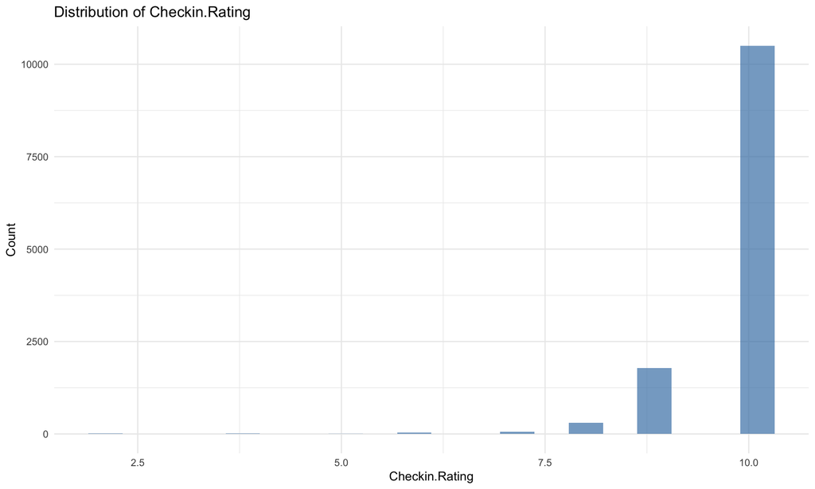

```
##
## Summary of Communication.Rating :
##    Min. 1st Qu.  Median    Mean 3rd Qu.    Max.    NA's
##   2.000  10.000  10.000   9.779  10.000  10.000    2970
```

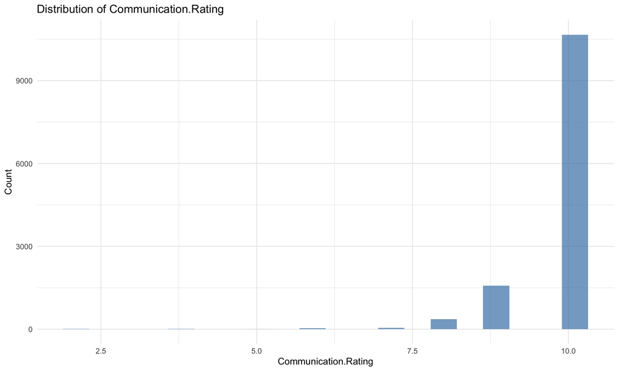

```
##
## Summary of Location.Rating :
##    Min. 1st Qu.  Median    Mean 3rd Qu.    Max.    NA's
##   2.000   9.000  10.000   9.557  10.000  10.000    2971
```

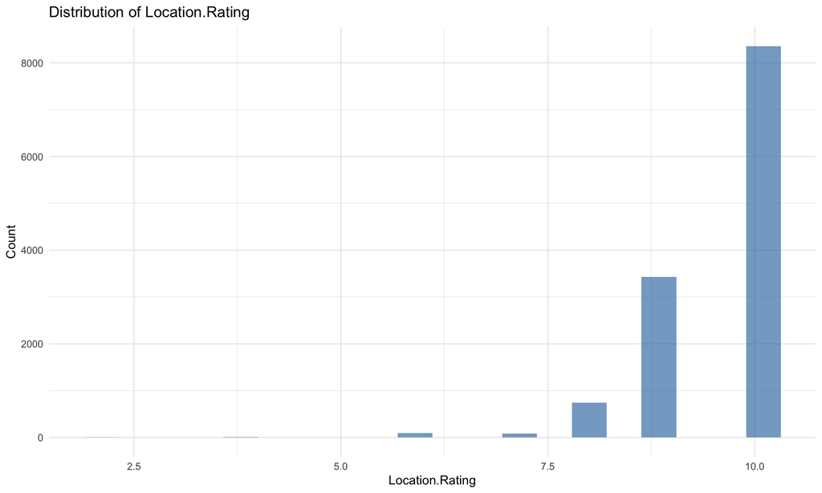

```
##
## Summary of Value.Rating :
##    Min. 1st Qu.  Median    Mean 3rd Qu.    Max.    NA's
##   2.000   9.000  10.000   9.458  10.000  10.000    2972
```

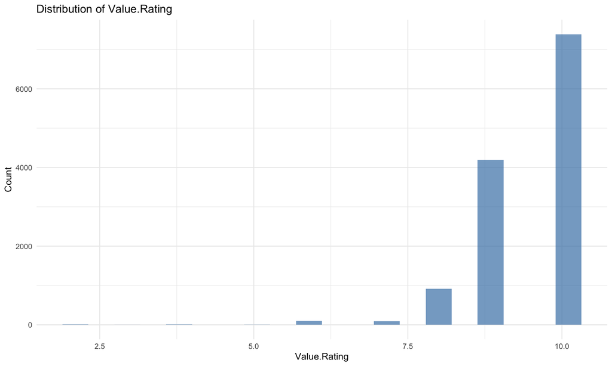

```r
# Check if reviews column exists
if("reviews" %in% names(train_data)) {
  # Summary of review counts
  review_summary <- summary(train_data$reviews)
  print(review_summary)

  # Distribution of review counts
  ggplot(train_data, aes(x = reviews)) +
    geom_histogram(bins = 30, fill = "steelblue", alpha = 0.7) +
    labs(title = "Distribution of Review Counts",
         x = "Number of Reviews",
         y = "Count") +
    theme_minimal()

  # Log-transformed distribution for skewed data
  ggplot(train_data %>% filter(reviews > 0), aes(x = reviews)) +
    geom_histogram(bins = 30, fill = "steelblue", alpha = 0.7) +
    scale_x_log10() +
    labs(title = "Distribution of Review Counts (Log Scale)",
         x = "Number of Reviews (Log Scale)",
         y = "Count") +
    theme_minimal()
}

# Check for rating columns
rating_columns <- names(train_data)[grepl("rating", names(train_data), ignore.case = TRUE)]

if(length(rating_columns) > 0) {
  # Distribution of ratings
  for(col in rating_columns) {
    # Summary statistics
    rating_summary <- summary(train_data[[col]])
    cat(paste("\nSummary of", col, ":\n"))
    print(rating_summary)

    # Plot distribution
    p <- ggplot(train_data, aes(x = !!sym(col))) +
      geom_histogram(bins = 20, fill = "steelblue", alpha = 0.7) +
      labs(title = paste("Distribution of", tools::toTitleCase(col)),
           x = tools::toTitleCase(col),
           y = "Count") +
      theme_minimal()

    print(p)

    # If price is available, check correlation with ratings
    if("price" %in% names(train_data)) {
      # Scatter plot
      p2 <- ggplot(train_data, aes(x = !!sym(col), y = price)) +
        geom_point(alpha = 0.3, color = "steelblue") +
        geom_smooth(method = "lm", color = "red") +
        labs(title = paste("Relationship Between", tools::toTitleCase(col), "and Price"),
             x = tools::toTitleCase(col),
             y = "Price (Euro)") +
        theme_minimal()

      print(p2)
    }
  }
}
```

## Correlation Analysis

Let’s examine correlations between numeric variables to understand relationships.

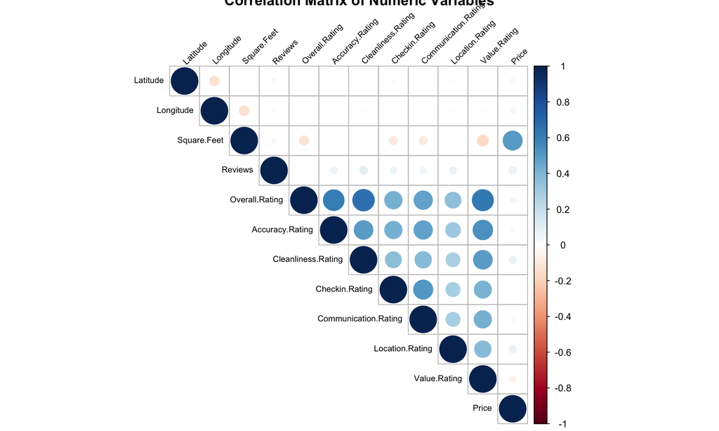

```r
# Select numeric columns
numeric_columns <- train_data %>%
  select_if(is.numeric) %>%
  # Remove ID columns and other non-meaningful numeric columns
  select(-matches("id|_id$|index|^X$"), -one_of("latitude", "longitude"))

# If there are numeric columns, create correlation matrix
if(ncol(numeric_columns) > 1) {
  # Calculate correlation matrix
  cor_matrix <- cor(numeric_columns, use = "pairwise.complete.obs")

  # Plot correlation matrix
  corrplot(cor_matrix, method = "circle", type = "upper",
           tl.col = "black", tl.srt = 45, tl.cex = 0.7,
           title = "Correlation Matrix of Numeric Variables")

  # Display top correlations with price (if available)
  if("price" %in% names(numeric_columns)) {
    price_cors <- cor_matrix["price", ]
    price_cors <- price_cors[order(abs(price_cors), decreasing = TRUE)]
    price_cors <- price_cors[price_cors != 1]  # Remove self-correlation

    cat("\nTop correlations with price:\n")
    print(head(price_cors, 10))
  }
}
```

# Creating a Demand Proxy

Since our dataset may not have a direct demand measure, we need to create a proxy based on available data.

```r
# Check which columns we have available for demand proxy creation
potential_demand_columns <- c("reviews", "availability_365", "availability_90", "availability_30")
available_columns <- potential_demand_columns[potential_demand_columns %in% names(train_data)]

cat("Available columns for demand proxy creation:", paste(available_columns, collapse = ", "), "\n")
```

```
## Available columns for demand proxy creation:
```

```r
# Create a simple demand proxy based on available data
train_data_with_proxy <- train_data

# If review data is available
if("reviews" %in% names(train_data)) {
  # Normalize reviews (higher = more demand)
  max_reviews <- max(train_data$reviews, na.rm = TRUE)
  train_data_with_proxy$review_score <- train_data$reviews / max_reviews
}

# If availability data is available (lower = more demand)
availability_cols <- c("availability_365", "availability_90", "availability_30")
available_avail_cols <- availability_cols[availability_cols %in% names(train_data)]

if(length(available_avail_cols) > 0) {
  # Choose the shortest time period available for more recent data
  avail_col <- available_avail_cols[length(available_avail_cols)]
  max_avail <- as.numeric(gsub("availability_", "", avail_col))

  # Invert availability (1 - availability/max_days) so higher = more demand
  train_data_with_proxy$availability_score <- 1 - (train_data[[avail_col]] / max_avail)
}

# Combine available proxies
if(exists("review_score", where = train_data_with_proxy) &&
   exists("availability_score", where = train_data_with_proxy)) {
  # Combined demand score (average of review and availability scores)
  train_data_with_proxy$demand_proxy <- (train_data_with_proxy$review_score +
                                        train_data_with_proxy$availability_score) / 2
} else if(exists("review_score", where = train_data_with_proxy)) {
  train_data_with_proxy$demand_proxy <- train_data_with_proxy$review_score
} else if(exists("availability_score", where = train_data_with_proxy)) {
  train_data_with_proxy$demand_proxy <- train_data_with_proxy$availability_score
} else {
  # If no good proxy is available, we'll need to use price as an indirect indicator
  if("price" %in% names(train_data)) {
    # Normalize price (assuming higher price = higher demand, which is simplistic)
    max_price <- max(train_data$price, na.rm = TRUE)
    train_data_with_proxy$demand_proxy <- train_data$price / max_price
    cat("Using normalized price as a fallback demand proxy\n")
  } else {
    cat("No suitable demand proxy could be created from available data\n")
  }
}
```

```
## No suitable demand proxy could be created from available data
```

```r
# Visualize the demand proxy if created
if("demand_proxy" %in% names(train_data_with_proxy)) {
  # Distribution of demand proxy
  ggplot(train_data_with_proxy, aes(x = demand_proxy)) +
    geom_histogram(bins = 30, fill = "steelblue", alpha = 0.7) +
    labs(title = "Distribution of Demand Proxy",
         x = "Demand Proxy (0-1 scale)",
         y = "Count") +
    theme_minimal()

  # If we have neighborhood data, show average demand by neighborhood
  if("neighbourhood" %in% names(train_data) || "neighborhood" %in% names(train_data)) {
    # Determine which column to use
    neighborhood_col <- ifelse("neighbourhood" %in% names(train_data), "neighbourhood", "neighborhood")

    # Calculate average demand by neighborhood
    avg_demand_by_neighborhood <- train_data_with_proxy %>%
      group_by(!!sym(neighborhood_col)) %>%
      summarise(
        avg_demand = mean(demand_proxy, na.rm = TRUE),
        count = n()
      ) %>%
      filter(count >= 10) %>%  # Only include neighborhoods with at least 10 listings
      arrange(desc(avg_demand))

    # Top 15 neighborhoods by average demand
    top_demand_neighborhoods <- head(avg_demand_by_neighborhood, 15)
    kable(top_demand_neighborhoods, caption = "Top 15 Neighborhoods by Average Demand")

    # Visualize average demand by neighborhood
    ggplot(top_demand_neighborhoods,
           aes(x = reorder(!!sym(neighborhood_col), avg_demand), y = avg_demand)) +
      geom_bar(stat = "identity", fill = "steelblue") +
      coord_flip() +
      labs(title = "Top 15 Neighborhoods by Average Demand",
           x = "Neighborhood",
           y = "Average Demand Proxy") +
      theme_minimal()
  }
}
```

# Conclusion and Next Steps

## Next Steps

1. **Feature Engineering**: Create additional variables such as:
   - Price per person (price/accommodates)
   - Distance to city center or tourist hotspots
   - Seasonal indicators
2. **Data Preparation**:
   - Handle missing values appropriately
   - Encode categorical variables
   - Scale and normalize numeric features
3. **Modeling**:
   - Develop regression models to predict price
   - Develop classification models for demand categories
   - Compare different algorithms and evaluate performance
4. **Simulations**:
   - Create simulations for different scenarios affecting rental demand
   - Analyze potential impacts of market changes

The next step is to proceed with data preprocessing and feature engineering, followed by predictive modeling as outlined in the subsequent R Markdown files.